# 10_PINN_Loss_and_Weighting_textbook

**Scientific Machine Learning:**  
**Regularization, MAP Estimation, and Loss Weighting**

1. Why a Loss Function Needs More Than Data
   1. When Data Alone Are Not Enough
   2. Adding a Term to the Objective
2. Overfitting and Regularization
   1. A Measure of Fit and a Measure of Magnitude
3. Probabilistic Linear Regression
   1. Generative Model
   2. Frequentist View of Linear Regression
   3. Bayesian View of Linear Regression
4. From Statistical Priors to Physical Priors
   1. What Engineers Know Before Seeing Data
   2. Is the Physics Loss a Regularizer?
5. A Naive PINN
   1. The Problem
   2. Naive PINN
6. Fixed Weighting
   1. A Well-Chosen Weight Recovers the Solution
   2. A Badly Chosen Weight Converges to the Wrong Answer
   3. Two Limitations of a Fixed Weight
7. Adaptive Weighting
   1. The Optimizer Sees Gradients, Not Losses
   2. Gradient-Based Adaptive Weighting
   3. Moving-Average Adaptive Weighting
   4. What Adaptive Weighting Does Not Do
8. Hard Constraint by a Masking Function
   1. Building the Boundary Condition into the Output
   2. Where the Argument Ends

Summary

## Learning Objectives

After studying this notebook, you should be able to

- explain why a data-only objective is often insufficient, and what an added term contributes;
- read a regularized loss as a measure of fit plus a measure of the magnitude of the coefficients, and explain why an overfitted model has large coefficients in the first place;
- derive the regularized loss from Bayes' theorem as a maximum a posteriori estimate, and show that ridge regression is MAP estimation under a Gaussian prior;
- describe the PDE residual as a prior over functions, and state precisely in what sense it is and is not a regularizer;
- recognize the failure of a naive PINN, a total loss that falls convincingly while neither condition is satisfied, on the one-dimensional Poisson problem;
- explain why a fixed weight can recover the solution or converge to a wrong one, and why even a right value does not stay right;
- explain why the optimizer responds to the gradient of each term rather than to its value, and derive the gradient-based adaptive weighting rule from that fact;
- explain why the measured weights should be smoothed by a moving average, and what the smoothing does and does not change;
- build a boundary condition into the network output with a masking function, and say what the construction removes from the objective and what it costs.

# 1. Why a Loss Function Needs More Than Data

In **Physics-informed Neural Networks (PINN)**, the governing equation, the boundary conditions and the initial condition were all treated alike. Each was written as a residual, squared, averaged over a set of points, and added to the loss:

$$ \mathcal{L} = \mathcal{L}_{\text{PDE}} + \mathcal{L}_{\text{BC}} + \mathcal{L}_{\text{IC}} + (\mathcal{L}_{\text{DATA}}) . $$

Nothing in this construction forces the network to satisfy any of the conditions. The optimizer is only asked to make the sum of the violations small, and a condition enforced in this way, by a penalty that is minimized rather than an equation that is imposed, is called a **soft constraint**. Every term of a PINN loss is a soft constraint.

Adding a penalty term to a loss is a well-established idea in machine learning, where it is known as **regularization**. It comes with a theory: what a penalty term expresses, why it improves the solution, and how its weight should be chosen. The purpose of this notebook is to read the PINN loss through that theory. The physics terms will turn out to be regularizers in the precise sense of the word, and the theory of regularization will tell us what the weights of the loss mean and how to set them, which the earlier notebooks left open.

To see the mechanism in its simplest form, we begin with an ordinary regression problem that contains no physics at all, and return to the PINN in Section 4.

## 1.1. When Data Alone Are Not Enough

In supervised learning the parameters of a model are chosen by minimizing a measure of disagreement with observations,

$$ \theta^\star=\arg\min_\theta\;\mathcal{L}_{\text{data}}(\theta), \qquad \mathcal{L}_{\text{data}}=\frac{1}{N}\sum_{i=1}^{N}\left(y_i-\hat{y}_i(\theta)\right)^2 . $$

This is the whole of the objective in a first course, and for a large dataset drawn from a well-behaved distribution it is often enough. Engineering data are rarely like that. Measurements are few, because each one costs an experiment. They are noisy, because instruments are. They cover the operating region that happened to be tested rather than the one of interest. And the model typically has more parameters than there are measurements to constrain them.

## 1.2. Adding a Term to the Objective

Choosing among them requires information from somewhere other than the data, and the standard way to supply it is to add a term to the objective,

$$ \mathcal{L}=\mathcal{L}_{\text{data}}+\lambda\,\mathcal{L}_{\text{reg}} . $$

This is regularization, and in its usual presentation it arrives as a trick: a penalty on large parameters that happens to improve test error, with $\lambda$ tuned by cross-validation. That description is operationally correct and conceptually empty. It says nothing about what the second term means, where it should come from, or how $\lambda$ should be chosen when there are four such terms rather than one, which is exactly the situation in a physics-informed neural network.

A better account is available, and the rest of this section is built on it.

# 2. Overfitting and Regularization

## 2.1. A Measure of Fit and a Measure of Magnitude

Regularization exists to control **overfitting**: a model that reproduces the data it was fitted to almost exactly, yet predicts badly everywhere else. It arises whenever a model has enough freedom to follow the noise as well as the signal, which in practice means whenever the number of adjustable parameters approaches the number of observations.

The mechanism is easiest to see in a small regression problem. Let $\{(x_i, y_i)\}_{i=1}^{N}$ be $N = 10$ noisy observations of a smooth function, and approximate that function by a linear combination of **radial basis functions** (RBFs),

$$ \hat y(x) \;=\; \sum_{j=1}^{d}\theta_j\,\phi_j(x) \;=\; \Phi(x)\,\theta , \qquad \phi_j(x) \;=\; \exp\left(-\frac{(x - u_j)^2}{2\sigma^2}\right) , $$

where $u_j$ is the centre of the $j$-th basis function and $\sigma$ its width. A radial basis function depends on its input only through the distance $\lvert x - u_j \rvert$ from that centre, which is what the name records; the Gaussian form above is the usual choice.

Here $d = 10$ centres are placed one at each observation, with width $\sigma = 1$ against a centre spacing of $1$. The model is linear in its parameters, so fitting it is the ordinary least-squares problem

$$ \min_\theta \; \lVert \Phi\theta - y \rVert_2^2 , \qquad \Phi_{ij} = \phi_j(x_i) , $$

and no neural network is involved. Because $d = N$, the design matrix $\Phi$ is square and, for these centres and this width, well conditioned, so the fit reproduces every observation exactly. Whatever goes wrong next is therefore a property of the model and not of the arithmetic.

The ten radial basis functions are fitted by least squares, and the result is shown twice: the fitted curve against the data, and the fitted coefficients as a stem plot. The second panel is the one to look at.

```python
import numpy as np
from matplotlib import pyplot as plt
%matplotlib inline

x = np.linspace(-4.5, 4.5, 10).reshape(-1, 1)
y = np.array([0.9819, 0.7973, 1.9737, 0.1838, 1.3180,
              -0.8361, -0.6591, -2.4701, -2.8122, -6.2512]).reshape(-1, 1)

d = 10
u = np.linspace(-4.5, 4.5, d)
sigma = 1

xp = np.linspace(-5, 5, 501).reshape(-1, 1)
Phi = np.exp(-(x - u)**2/(2*sigma**2))
Phip = np.exp(-(xp - u)**2/(2*sigma**2))

theta = np.linalg.solve(Phi.T@Phi, Phi.T@y)

print('coefficients from %.1f to %.1f' % (theta.min(), theta.max()))
print('data          from %.1f to %.1f' % (y.min(), y.max()))
print('RSS = %.2e' % np.linalg.norm(y - Phi@theta)**2)
```

```
coefficients from -14.9 to 15.6
data          from -6.3 to 2.0
RSS = 2.11e-26
```

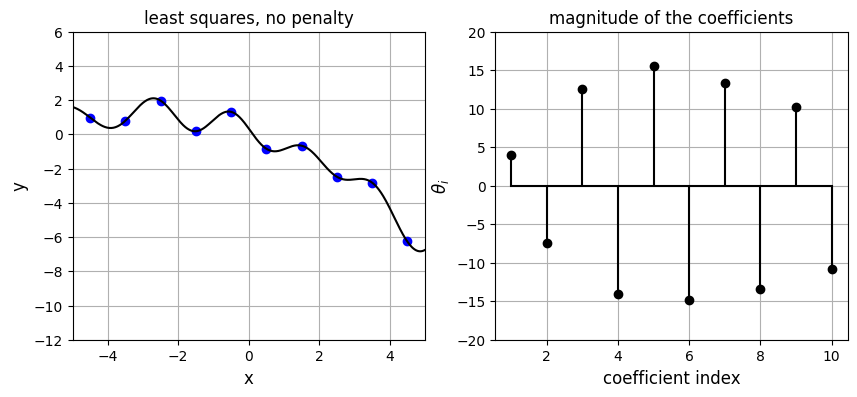

```python
plt.figure(figsize = (10, 4))

plt.subplot(1, 2, 1)
plt.plot(x, y, 'bo')
plt.plot(xp, Phip@theta, 'k')
plt.axis([-5, 5, -12, 6])
plt.grid(True)
plt.xlabel('x', fontsize = 12)
plt.ylabel('y', fontsize = 12)
plt.title('least squares, no penalty', fontsize = 12)

plt.subplot(1, 2, 2)
plt.stem(np.arange(1, d+1), theta, linefmt = 'k', markerfmt = 'ko', basefmt = 'k')
plt.ylim([-20, 20])
plt.grid(True)
plt.xlabel(r'coefficient index', fontsize = 12)
plt.ylabel(r'$\theta_i$', fontsize = 12)
plt.title('magnitude of the coefficients', fontsize = 12)

plt.show()
```

The fitted curve passes through all ten observations, with a residual sum of squares of zero to machine precision, and oscillates between them. The coefficients account for that oscillation. They run from about $-14.9$ to $+15.6$ and alternate in sign from one centre to the next, while the observations themselves lie between $-6.3$ and $+2.0$. The model therefore produces outputs of order one as a sum of contributions of order fifteen that very nearly cancel.

This near-cancellation is the mechanism of overfitting, not an incidental symptom of it. A curve built from smooth basis functions can be forced through scattered points only if large positive and large negative contributions cancel almost everywhere and fail to cancel exactly at the observations. Such cancellation is delicate: a small change in the data requires a large change in the coefficients, which is what it means for an estimator to have high **variance**. The model has fitted the noise, and the price of doing so is the magnitude of its coefficients.

This observation suggests its own remedy. Overfitting is accompanied by parameters of large magnitude, so the magnitude of the parameters should itself carry a cost. The objective then balances two quantities rather than one,

$$ \begin{align*} \text{total cost} \;=\;&\underbrace{\text{measure of fit}}_{\text{RSS}(\theta)} \;+\;\lambda\cdot\underbrace{\text{measure of magnitude of coefficients}}_{\lVert\theta\rVert_2^2} \\ \\ \implies\;&\min_\theta\;\lVert\Phi\theta-y\rVert_2^2+\lambda\lVert\theta\rVert_2^2 , \end{align*} $$

where the coefficient $\lambda\ge0$ fixes the rate of exchange between the two terms. For $\lambda=0$ the second term is absent and the estimate reduces to ordinary least squares; in the limit $\lambda\to\infty$ the first term is ignored and every coefficient is driven to zero. The useful regime lies between these two extremes. The resulting estimator is known as **ridge regression**.

The same problem is now solved with the penalty added, at $\lambda = 0.1$.

```python
lamb = 0.1

theta_r = np.linalg.solve(Phi.T@Phi + lamb*np.eye(d), Phi.T@y)

print('largest coefficient   %.1f  ->  %.1f' % (np.abs(theta).max(), np.abs(theta_r).max()))
print('RSS                   %.2e  ->  %.2f' % (np.linalg.norm(y - Phi@theta)**2,
                                                np.linalg.norm(y - Phi@theta_r)**2))
print('number of exactly zero coefficients: %d' % np.sum(theta_r == 0))
```

```
largest coefficient   15.6  ->  5.0
RSS                   2.11e-26  ->  4.60
number of exactly zero coefficients: 0
```

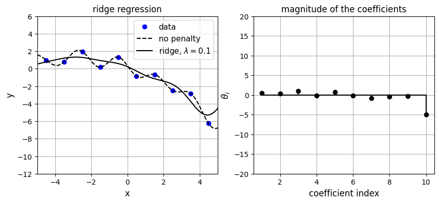

```python
plt.figure(figsize = (10, 4))

plt.subplot(1, 2, 1)
plt.plot(x, y, 'bo')
plt.plot(xp, Phip@theta, 'k--')
plt.plot(xp, Phip@theta_r, 'k')
plt.legend(['data', 'no penalty', 'ridge, $\\lambda = 0.1$'], fontsize = 11)
plt.axis([-5, 5, -12, 6])
plt.grid(True)
plt.xlabel('x', fontsize = 12)
plt.ylabel('y', fontsize = 12)
plt.title('ridge regression', fontsize = 12)

plt.subplot(1, 2, 2)
plt.stem(np.arange(1, d+1), theta_r, linefmt = 'k', markerfmt = 'ko', basefmt = 'k')
plt.ylim([-20, 20])
plt.grid(True)
plt.xlabel(r'coefficient index', fontsize = 12)
plt.ylabel(r'$\theta_i$', fontsize = 12)
plt.title('magnitude of the coefficients', fontsize = 12)

plt.show()
```

With the penalty in place the fitted curve is smooth and passes near the observations rather than through them. The largest coefficient has fallen by a factor of three, and the alternation of signs from one centre to the next has largely disappeared. The residual sum of squares is no longer zero, so the fit to the training data is strictly worse than before. This is the intended effect and not a failure: a small amount of bias has been accepted in exchange for a large reduction in variance, and the smooth curve is the better description of whatever process generated the observations.

One feature of the result deserves attention: not a single coefficient is exactly zero. The $L_2$ penalty shrinks every coefficient toward the origin and, except by coincidence, sends none of them all the way there. It therefore governs how large the model may be, not which basis functions it may use.

Sweeping $\lambda$ over five decades and recording all ten coefficients at each value, with $\lambda$ on a logarithmic axis, gives what is called a regularization path.

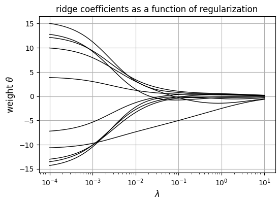

```python
lambs = np.logspace(-4, 1, 200)

theta_record = []
for k in range(len(lambs)):
    th = np.linalg.solve(Phi.T@Phi + lambs[k]*np.eye(d), Phi.T@y)
    theta_record.append(th.ravel())

theta_record = np.array(theta_record)

plt.figure(figsize = (6, 4))
plt.semilogx(lambs, theta_record, 'k', linewidth = 1)
plt.grid(True)
plt.xlabel(r'$\lambda$', fontsize = 12)
plt.ylabel(r'weight $\theta$', fontsize = 12)
plt.title('ridge coefficients as a function of regularization', fontsize = 12)
plt.show()
```

Every trace begins at its unregularized value on the left, where the coefficients are large and of both signs, and every one of them contracts toward zero as $\lambda$ increases.

# 3. Probabilistic Linear Regression

Section 2 left two questions unanswered. The penalty $\lVert\theta\rVert_2^2$ was chosen for convenience, and nothing was said about why that particular measure of magnitude should be the right one; the coefficient $\lambda$ was set by hand, and nothing in the fit itself determines it. Both are answered by describing the same regression problem in the language of probability, which is the subject of this chapter.

In traditional supervised learning, data is assumed to be fixed, and the model is optimized to fit it as closely as possible. In contrast, the probabilistic viewpoint assumes that the generative model comes first. This model, though unknown, gives rise to the observed data via a stochastic process.

From this perspective, the dataset is seen as a realization of a random process governed by an underlying distribution. Our goal is to infer this distribution - or aspects of it, such as its parameters - using the observed data. This leads to the broader framework of generative modeling, where learning becomes a process of probabilistic inference.

## 3.1. Generative Model

We begin with a **generative perspective**: assume there exists a true, underlying linear relationship between $x$ and $y$, but our observations are corrupted by noise.

Given observed data:

$$ D = \{(x_1, y_1), (x_2, y_2), \cdots, (x_m, y_m)\} $$

We assume each output $y_i$ is generated by a linear function of the input $x_i$ with additive Gaussian noise:

$$ y = \omega^T x + \varepsilon, \quad \varepsilon \sim \mathcal{N}(0, \sigma^2) $$

This leads to the conditional likelihood:

$$ P(y \mid x \,;\, \omega) = \mathcal{N}(\omega^T x, \sigma^2) $$

That is, for a given input $x$, the output $y$ is normally distributed around the mean $\omega^T x$, with variance $\sigma^2$ reflecting observation noise.

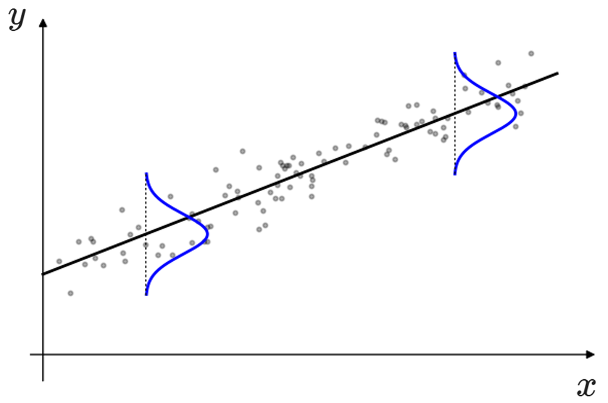

## 3.2. Frequentist View of Linear Regression

In the frequentist approach, the parameters $\omega$ and $\sigma^2$ are treated as fixed but unknown. Our goal is to estimate them using Maximum Likelihood Estimation (MLE).

Given the dataset:

$$ D = \{(x_1, y_1), (x_2, y_2), \cdots, (x_m, y_m)\} $$

and the generative model:

$$ y_i = \omega^T x_i + \varepsilon_i, \quad \varepsilon_i \sim \mathcal{N}(0, \sigma^2) $$

We assume that each $y_i$ is independently sampled:

$$ P(y_i \mid x_i; \omega, \sigma^2) = \frac{1}{\sqrt{2\pi \sigma^2}} \exp\left( -\frac{1}{2\sigma^2} (y_i - \omega^T x_i)^2 \right) $$

**Likelihood and Log-Likelihood**

The likelihood of the parameters given the dataset is:

$$ \begin{align*} \mathcal{L}(\omega, \sigma^2) = P(D \mid \theta) = P(D \,;\, \theta) &= P\left(y_1,y_2,\cdots,y_m \mid x_1,x_2,\cdots,x_m; \; \underbrace{\omega, \sigma}_{\theta}\right) \\ &= \prod_{i=1}^m P(y_i \mid x_i; \omega, \sigma^2) \end{align*} $$

Taking the logarithm (log-likelihood):

$$ \begin{align*} \ell (\omega,\sigma^2) = \log \mathcal{L}(\omega,\sigma^2) &= \log \prod\limits^m_{i=1}P\left(y_i \mid x_i\,; \omega,\sigma^2 \right)\\ &= \sum\limits^m_{i=1}\log P \left(y_i \mid x_i\,; \omega, \sigma^2 \right)\\ &= \sum\limits^m_{i=1}\log \frac{1}{\sqrt{2\pi\sigma^2}}\exp{\left(-\frac{\left(y_i - \omega^Tx_i \right)^2}{2\sigma^2}\right)}\\ &= \sum\limits^m_{i=1}\left\{ -\frac{1}{2}\log \left(2\pi\sigma^2 \right) - \frac{\left(y_i - \omega^Tx_i \right)^2}{2\sigma^2}\right\} \end{align*} $$

**Maximum Likelihood Estimation (MLE)**

To estimate parameters, we maximize the log-likelihood:

$$ \hat{\theta}_{MLE} = {\arg\max_{\omega, \sigma^2}} \;\; \ell(\omega, \sigma^2) $$

(1) Focusing first on maximizing with respect to $\omega$:

$$ \begin{align*} \hat{\omega}_{MLE} &= \arg\max_{\omega} \;- \frac{1}{2\sigma^2}\sum\limits^m_{i=1} \left(y_i-\omega^Tx_i \right)^2\\ &= \arg\min_{\omega} \frac{1}{2\sigma^2}\sum\limits^m_{i=1} \left(y_i-\omega^Tx_i \right)^2\\ &= \arg\min_{\omega} \sum\limits^m_{i=1} \left(y_i-\omega^Tx_i \right)^2 \end{align*} $$

This is exactly the **least-squares objective** from classical linear regression. (Amazing !)

Maximum likelihood estimation under a Gaussian noise model leads to the least-squares solution.

(2) Focusing then on $\sigma$:

$$ \begin{align*} \ell (\omega,\sigma^2) &= -\frac{m}{2}\log{2\pi}-m\log{\sigma}-\frac{1}{2\sigma^2}\sum\limits_{i=1}^m\left(y_i-\omega^T x_i\right)^2 \\\\ \frac{\partial \ell}{\partial \sigma} & =-\frac{m}{\sigma}+\frac{1}{\sigma^3}\sum\limits_{i=1}^m\left(y_i-\omega^T x_i\right)^2=0 \quad \\\\ & \implies \; \hat \sigma^2_{MLE}=\frac{1}{m}\sum\limits_{i=1}^m\left(y_i-\omega^T x_i\right)^2 \end{align*} $$

**Big Lessons**

- MLE under Gaussian noise leads directly to least-squares regression
- Probabilistic modeling justifies the use of least-squares from first principles

**Lab:**

This example demonstrates that if a linear model is correctly specified and well estimated, then the residual errors (i.e., the differences between predicted and observed values) should approximately follow a Gaussian distribution:

$$ \varepsilon = y - \omega^T x \sim \mathcal{N}(0, \sigma^2) $$

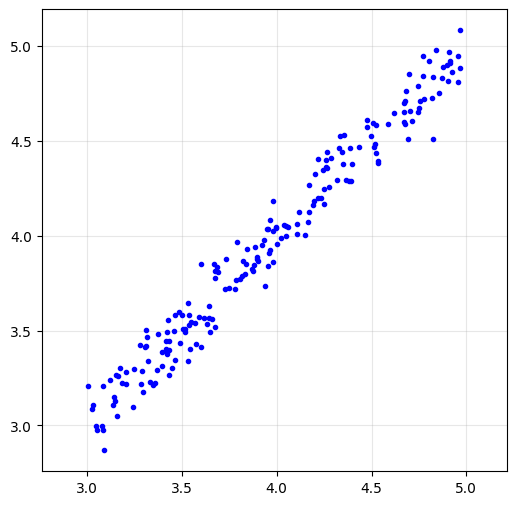

```python
m = 200

a = 1
x = 3 + 2*np.random.uniform(0, 1, [m, 1])
noise = 0.1*np.random.randn(m, 1)

y = a*x + noise

plt.figure(figsize = (6, 6))
plt.plot(x, y, 'b.')
plt.axis('equal')
plt.grid(alpha = 0.3)
plt.show()
```

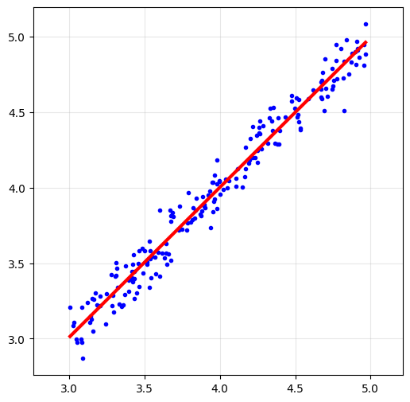

```python
# y = theta[1]*x + theta[0]
A = np.hstack([np.ones([m, 1]), x])

theta = np.linalg.solve(A.T@A, A.T@y).ravel()

# to plot the fitted line
xp = np.linspace(np.min(x), np.max(x))
yp = theta[1]*xp + theta[0]

plt.figure(figsize = (6, 6))
plt.plot(x, y, 'b.')
plt.plot(xp, yp, 'r', linewidth = 3)
plt.axis('equal')
plt.grid(alpha = 0.3)
plt.show()
```

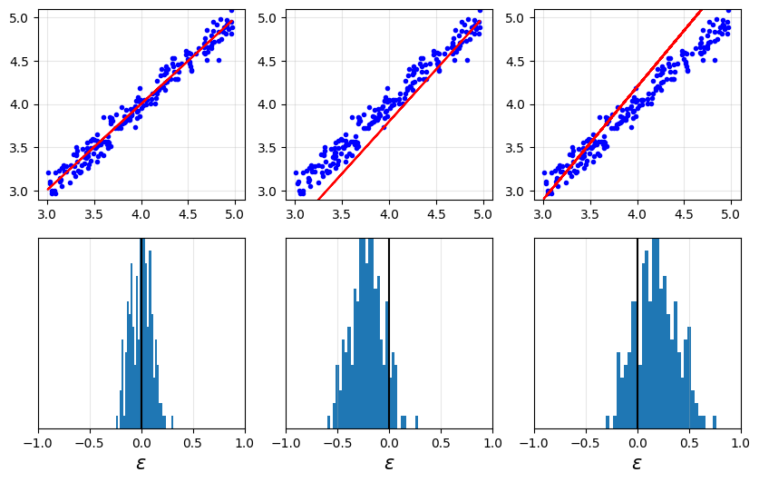

```python
yhat0 = theta[1]*x + theta[0]
err0 = yhat0 - y

yhat1 = 1.2*x - 1
err1 = yhat1 - y

yhat2 = 1.3*x - 1
err2 = yhat2 - y

plt.figure(figsize = (10, 6))

for k, (yhat, err) in enumerate([(yhat0, err0), (yhat1, err1), (yhat2, err2)]):
    plt.subplot(2, 3, k + 1)
    plt.plot(x, y, 'b.', x, yhat, 'r')
    plt.axis([2.9, 5.1, 2.9, 5.1])
    plt.grid(alpha = 0.3)

    plt.subplot(2, 3, k + 4)
    plt.hist(err, 31)
    plt.axvline(0, color = 'k')
    plt.xlabel(r'$\epsilon$', fontsize = 15)
    plt.yticks([])
    plt.axis([-1, 1, 0, 15])
    plt.grid(alpha = 0.3)

plt.show()
```

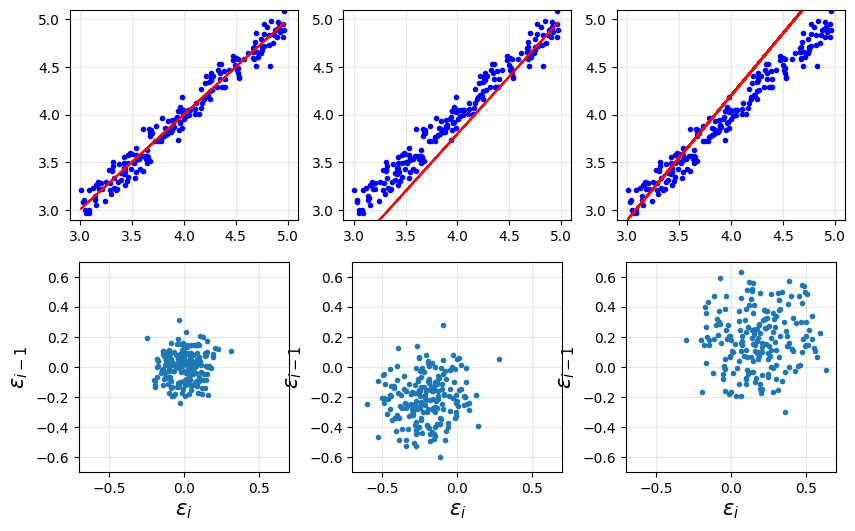

```python
plt.figure(figsize = (10, 6))

for k, (yhat, err) in enumerate([(yhat0, err0), (yhat1, err1), (yhat2, err2)]):
    plt.subplot(2, 3, k + 1)
    plt.plot(x, y, 'b.', x, yhat, 'r')
    plt.axis([2.9, 5.1, 2.9, 5.1])
    plt.grid(alpha = 0.3)

    plt.subplot(2, 3, k + 4)
    plt.plot(err[1:], err[:-1], '.')
    plt.axis([-0.7, 0.7, -0.7, 0.7])
    plt.gca().set_aspect('equal')
    plt.grid(alpha = 0.3)
    plt.xlabel(r'$\epsilon_i$', fontsize = 15)
    plt.ylabel(r'$\epsilon_{i-1}$', fontsize = 15)

plt.show()
```

Only the least-squares line leaves residuals that are centred at zero, bell-shaped, and without structure when each residual is plotted against the previous one. The two lines chosen by hand leave residuals that are shifted and drift along the line of points, which is the signature of a model that has not absorbed everything the data have to say. The Gaussian noise model is therefore not only an assumption behind least squares; it is also a check that the fit can be held to afterwards.

## 3.3. Bayesian View of Linear Regression

In the frequentist approach, we estimate the parameters $\omega$ by maximizing the likelihood (MLE), which implicitly assumes no prior information or a uniform prior over $\omega$. In contrast, the Bayesian approach treats $\omega$ as a random variable and incorporates prior beliefs about its distribution.

Bayesian linear regression not only provides a point estimate of $\omega$, but also quantifies uncertainty through its posterior distribution. This enables a principled approach to regularization and confidence assessment.

### 3.3.1. A Prior on $\omega$

Suppose we assume a Gaussian prior over the weight vector $\omega = \begin{bmatrix} \omega_0 \\ \omega_1 \end{bmatrix}$:

$$ P(\omega) = \mathcal{N}(0, \Sigma) = \mathcal{N}\left(0, \lambda^{-1} I\right) $$

This expresses our belief that $\omega$ is centered at zero, with uncertainty controlled by $\lambda$. A large $\lambda$ implies strong confidence that weights should be small (i.e., a stronger regularization effect).

The prior probability density is:

$$ P(\omega) = \frac{1}{(2\pi)^{D/2}} \exp\left( -\frac{\lambda}{2} \omega^T \omega \right) $$

This means that before seeing any data, we believe that the weights are centered around zero, with uncertainty (variance) controlled by the parameter $\lambda$.

Understanding this assumption is important: it formalizes the idea that we prefer simpler models (with smaller weights), unless the data provides strong evidence otherwise. This is the Bayesian interpretation of regularization.

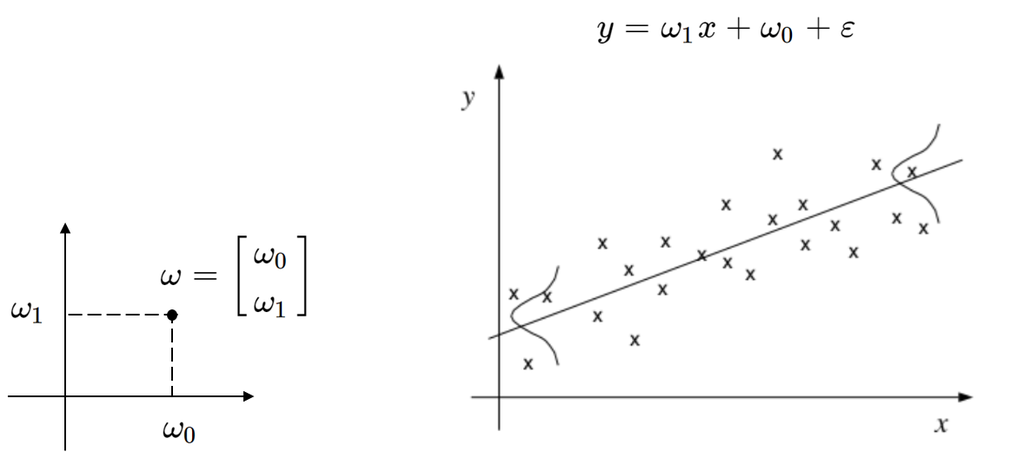

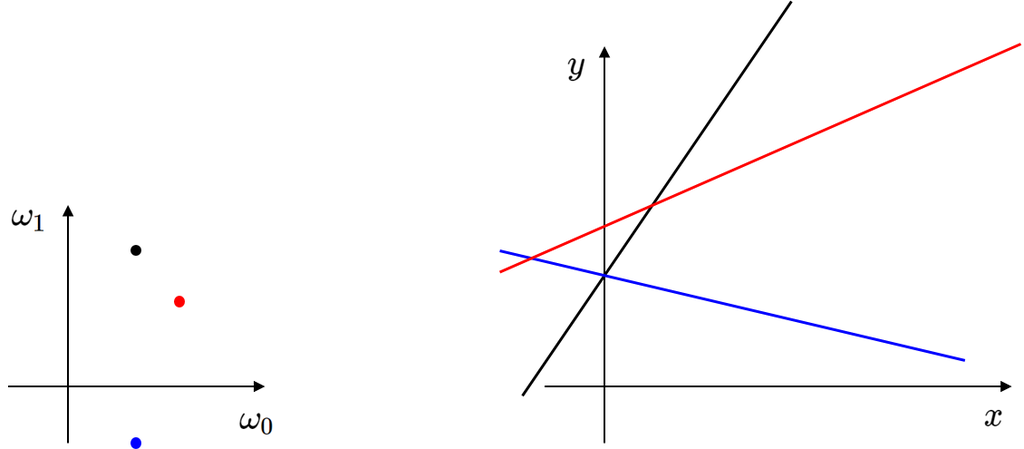

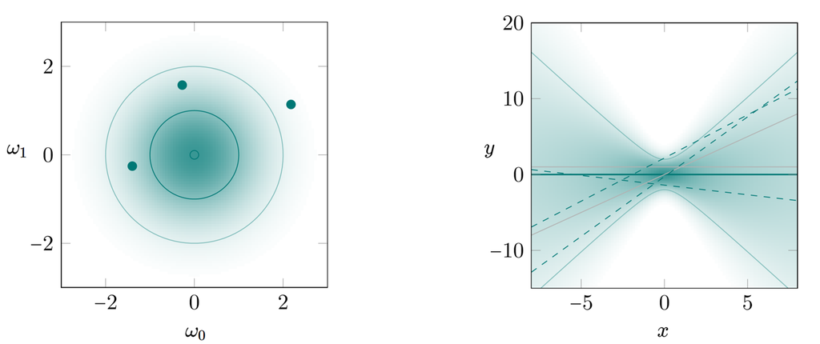

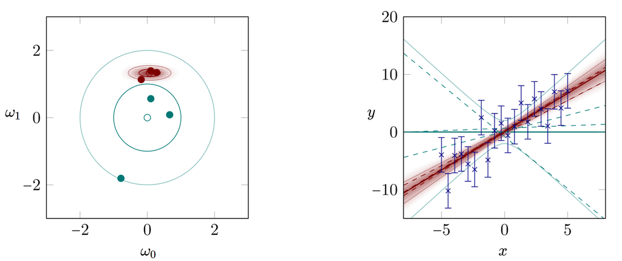

### 3.3.2. Posterior Distribution

By Bayes' Rule, the posterior distribution over $\omega$ given data $D$ is:

$$P(\omega \mid D) = \frac{P(D \mid \omega) P(\omega)}{P(D)}$$

Taking logarithms, we get the log-posterior:

$$\log P(\omega \mid D) = \log\frac{P(D \mid \omega)P(\omega)}{P(D)} = \log P(D \mid \omega) + \log P(\omega) - \underbrace{\log P(D)}_{\text{constant}}$$

Since $P(D)$ does not depend on $\omega$, we can treat it as a constant in optimization.

### 3.3.3. Maximum-a-Posteriori (MAP)

To find the most likely value of $\omega$ given the data (i.e., the mode of the posterior), we use MAP estimation:

$$ \begin{align*} \hat{\omega}_{MAP} &= \arg\max_{\omega} \; \log P(\omega \mid D)\\\\ &= \arg\max_{\omega} \; \left\{\log P(D \mid \omega) + \log P(\omega)\right\}\\\\ &= \arg\max_{\omega} \; \left\{ \sum\limits^m_{i=1}\left\{ -\frac{1}{2}\log\left(2\pi\sigma^2\right) - \frac{\left(y_i-\omega^Tx_i\right)^2}{2\sigma^2} \right\} -\frac{D}{2}\log (2\pi) - \frac{\lambda}{2}\omega^T\omega \right\}\\\\ &= \arg\min_{\omega} \; \frac{1}{2\sigma^2}\sum\limits^m_{i=1}\left(y_i - \omega^Tx_i\right)^2 + \frac{\lambda}{2}\omega^T\omega \quad \\&\text{ (ignoring constants and changing max to min)} \end{align*} $$

**Regularized Least Squares**

If we assume $\sigma^2 = 1$, the MAP objective becomes:

$$\hat{\omega}_{MAP} = \arg\min_{\omega} \left\{\sum\limits^m_{i=1}\left(y_i - \omega^Tx_i\right)^2 + \lambda\omega^T\omega \right\}$$

This is equivalent to ridge regression, also known as $L_2$-regularized linear regression. (Amazing !).

**Big Lesson**

- MLE assumes no prior and yields the least-squares solution
- MAP incorporates a Gaussian prior and yields $L_2$ regularization
- Bayesian inference provides a natural framework to balance data fit and model complexity

MAP estimation illustrates how Bayesian reasoning not only extends classical approaches but also provides a principled foundation for regularization and improved generalization.

# 4. From Statistical Priors to Physical Priors

## 4.1. What Engineers Know Before Seeing Data

The prior in Section 3 was weak and generic: parameters are probably not enormous. In an engineering problem, far stronger prior knowledge is usually available, and it has nothing to do with the parameters of any model. Mass is conserved. Momentum is conserved. Energy is conserved. Stress and strain are related by a constitutive law. The field satisfies a partial differential equation with prescribed boundary and initial conditions.

None of this is contained in a table of measurements, and all of it is more trustworthy than the measurements. The question is how to write it into an objective function.

Consider a governing equation written with all terms on one side,

$$ \frac{\partial u}{\partial t}+\mathcal{N}[u]=0, $$

where $\mathcal{N}$ collects the spatial operators. Let a neural network with parameters $\theta$ stand in for the solution, $u(x,t)\approx u_\theta(x,t)$. Because the network is differentiable and its derivatives are available exactly by automatic differentiation, the equation can be evaluated at any point of the domain. What comes back is the **residual**

$$ r_\theta(x,t)=\frac{\partial u_\theta}{\partial t}+\mathcal{N}[u_\theta], $$

which is zero wherever the network happens to satisfy the physics and nonzero elsewhere. Its mean square over a set of sampled collocation points is a number that measures how badly the physics is violated,

$$ \mathcal{L}_{\text{physics}}=\frac{1}{N_f}\sum_{i=1}^{N_f}\left\lvert r_\theta(x_i,t_i)\right\rvert^2 , $$

and adding it to the objective expresses a preference for networks that obey the equation:

$$ \mathcal{L}=\mathcal{L}_{\text{data}}+\lambda_f\,\mathcal{L}_{\text{physics}} . $$

This is the basic physics-informed neural network, and read in the light of Section 3 it is a MAP estimate whose prior is a physical law rather than a statement about parameter magnitudes.

## 4.2. Is the Physics Loss a Regularizer?

The question is worth answering carefully, because both possible answers mislead if stated flatly.

In the broad sense, yes. It is an additional term that restricts which solutions the optimizer is encouraged to find, it encodes knowledge not present in the data, and it enters the objective in the same place a regularizer does. Without it the network fits the observations; with it the network fits the observations while respecting the governing equation.

In the narrow sense used in statistical learning, no. A regularizer such as weight decay is a generic, problem-independent preference for small parameters, whose purpose is to control the effective capacity of the model and reduce variance. The physics term does none of that. It is problem-specific, it says nothing about capacity, and it can just as easily **increase** the difficulty of the optimization as reduce it. Its purpose is not to prevent overfitting but to impose a known constraint.

The accurate description is the middle one: the physics loss is a **soft constraint**, imposed by penalty, carrying domain knowledge into the objective.

The hierarchy $\text{regularization}\rightarrow\text{prior knowledge}\rightarrow\text{physical prior}\rightarrow\text{PINN}$ is a good guide to how the idea developed, provided the last arrow is understood as a change in the nature of the information and not merely in its name.

# 5. A Naive PINN

## 5.1. The Problem

The problem used throughout is the one-dimensional Poisson equation

$$ -u''(x) = (\alpha\pi)^2\sin(\alpha\pi x), \qquad x\in(0,1), $$

with homogeneous Dirichlet boundary conditions

$$ u(0) = u(1) = 0 , $$

and exact solution

$$ u(x) = \sin(\alpha\pi x) . $$

The parameter $\alpha$ sets the frequency of the solution and, through the factor $(\alpha\pi)^2$ in the forcing term, the scale of the PDE residual. The main experiments use $\alpha = 7$: four oscillations on the interval, and a forcing term of size $(7\pi)^2 \approx 484$.

**Setup**

NumPy, Matplotlib and PyTorch. All runs in this notebook work on a CPU; each of the long runs takes a few minutes.

```python
import numpy as np
import matplotlib.pyplot as plt

import torch
import torch.nn as nn

device = torch.device('cuda' if torch.cuda.is_available() else 'cpu')
print('Device:', device)
```

```
Device: cpu
```

**Model, points and loss terms**

The network takes $x$ and returns $u_\theta(x)$ directly. The collocation points are the interior points of a uniform grid, so that no collocation point coincides with a boundary point. One detail matters for every comparison in this notebook: `new_pinn()` resets the random seed before building the network, so that every model starts from the same weights, and every run uses the same points, optimizer and number of iterations. Whatever differs between two runs is therefore the loss and nothing else.

```python
alpha = 7.0
n_iter = 30000
lr = 1e-4
n_pde = 100

x_pde = torch.linspace(0, 1, n_pde + 2, device = device)[1:-1].reshape(-1, 1)
x_bc = torch.tensor([[0.0], [1.0]], device = device)
f_pde = (alpha*np.pi)**2*torch.sin(alpha*np.pi*x_pde)

x_pde.requires_grad_(True)

x_plot = torch.linspace(0, 1, 400, device = device).reshape(-1, 1)
x_np = x_plot.cpu().numpy().ravel()
u_true = np.sin(alpha*np.pi*x_np)

iteration = np.arange(1, n_iter + 1)

def new_pinn():
    torch.manual_seed(3)                       # every model starts from the same weights
    return nn.Sequential(nn.Linear(1, 64), nn.Tanh(),
                         nn.Linear(64, 64), nn.Tanh(),
                         nn.Linear(64, 64), nn.Tanh(),
                         nn.Linear(64, 1)).to(device)

def derivative(u, x):
    return torch.autograd.grad(u, x, torch.ones_like(u), create_graph = True)[0]
```

The boundary values stay at zero whatever $\alpha$ is; what $\alpha$ changes is the interior, which oscillates faster and needs a larger second derivative to match the forcing. The two conditions therefore live on very different scales, and the gap widens with $\alpha$, as the exact solution for three values of $\alpha$ shows.

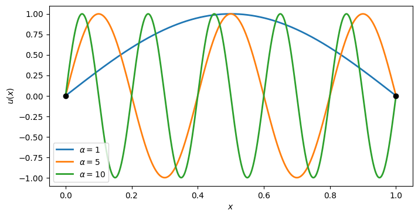

```python
x_line = np.linspace(0, 1, 1000)

plt.figure(figsize = (8, 4))
for a in [1, 5, 10]:
    plt.plot(x_line, np.sin(a*np.pi*x_line), linewidth = 2, label = r'$\alpha = %d$' % a)
plt.plot([0, 1], [0, 0], 'ko')
plt.xlabel('$x$')
plt.ylabel('$u(x)$')
plt.legend()
plt.show()
```

## 5.2. Naive PINN

The two conditions become two mean squared residuals, the equation over the collocation points and the boundary condition over the two end points,

$$ \mathcal{L}_{\mathrm{PDE}} = \frac{1}{N_f}\sum_{i=1}^{N_f}\bigl(-u_{\theta,xx}(x_i) - (\alpha\pi)^2\sin(\alpha\pi x_i)\bigr)^2 , \qquad \mathcal{L}_{\mathrm{BC}} = \frac{u_\theta(0)^2 + u_\theta(1)^2}{2} , $$

and the most natural thing to do is to add them,

$$ \mathcal{L}_{\mathrm{total}} = \mathcal{L}_{\mathrm{PDE}} + \mathcal{L}_{\mathrm{BC}} . $$

This is the **naive PINN**, and it is what most first implementations do. The two losses are recorded separately throughout training, because the question of this chapter is not whether the total falls but what each term does while it falls.

```python
net_naive = new_pinn()
optimizer = torch.optim.Adam(net_naive.parameters(), lr = lr)

loss_pde_hist = np.zeros(n_iter)
loss_bc_hist = np.zeros(n_iter)

for k in range(n_iter):
    optimizer.zero_grad()

    u = net_naive(x_pde)
    u_x = derivative(u, x_pde)
    u_xx = derivative(u_x, x_pde)

    loss_pde = torch.mean((-u_xx - f_pde)**2)
    loss_bc = torch.mean(net_naive(x_bc)**2)
    loss = loss_pde + loss_bc

    loss.backward()
    optimizer.step()

    loss_pde_hist[k] = loss_pde.item()
    loss_bc_hist[k] = loss_bc.item()

print('Naive PINN | PDE %.3e | BC %.3e' % (loss_pde.item(), loss_bc.item()))
```

```
Naive PINN | PDE 3.376e+04 | BC 5.646e+01
```

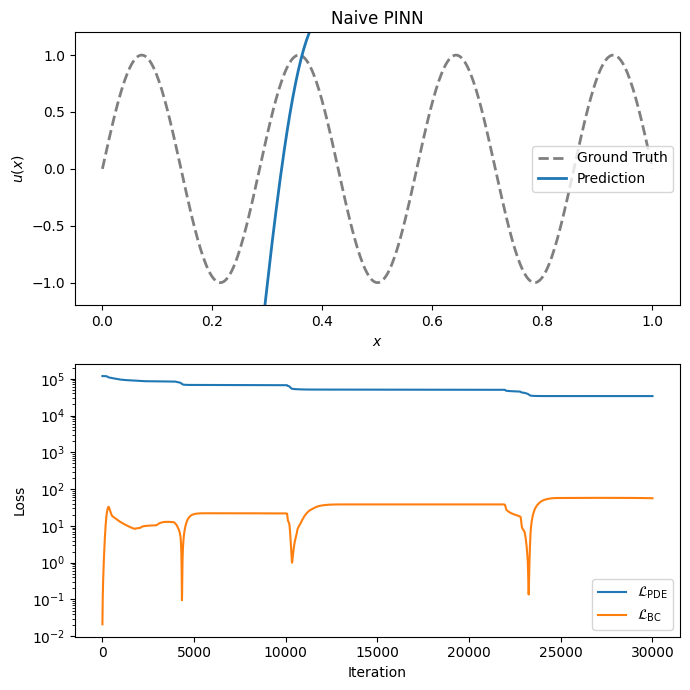

```python
with torch.no_grad():
    u_naive = net_naive(x_plot).cpu().numpy().ravel()

plt.figure(figsize = (7, 7))

plt.subplot(2, 1, 1)
plt.plot(x_np, u_true, 'k--', linewidth = 2, label = 'Ground Truth', alpha = 0.5)
plt.plot(x_np, u_naive, linewidth = 2, label = 'Prediction')
plt.title('Naive PINN')
plt.xlabel('$x$')
plt.ylabel('$u(x)$')
plt.ylim(-1.2, 1.2)
plt.legend()

plt.subplot(2, 1, 2)
plt.semilogy(iteration, loss_pde_hist, label = r'$\mathcal{L}_{\mathrm{PDE}}$')
plt.semilogy(iteration, loss_bc_hist, label = r'$\mathcal{L}_{\mathrm{BC}}$')
plt.xlabel('Iteration')
plt.ylabel('Loss')
plt.legend()

plt.tight_layout()
plt.show()
```

The result is not a slightly wrong solution; it is a different function altogether. The prediction is a steep curve that leaves the plotting window, the PDE residual is still enormous, and the boundary loss says that the two end values are of order ten rather than zero. Neither condition is satisfied, and yet nothing in the run would have raised an alarm: the total loss fell for the whole run. The lower panel shows why. The PDE loss is three orders of magnitude larger than the boundary loss throughout, and it is the only one that descends; the boundary loss starts small, because an untrained network returns values near zero at the ends, and is driven *up* by orders of magnitude as the optimizer trades the boundary values away for a smaller residual. A loss that is falling says that the optimizer is doing its job. It does not say that the job was well posed. The simplest remedy is to weight the two terms differently, which is the subject of the next chapter; what the optimizer was actually doing is examined in Section 7.1.

# 6. Fixed Weighting

Fixed weighting sets the coefficient once and never touches it again. If the two gradient norms are mismatched by a known factor, a constant can bring the two contributions to the same length, and the method corrects the imbalance when the factor is known. The two runs of this chapter use the same network, starting weights, points, optimizer and number of iterations as the naive run of Section 5.2, and differ from it in one constant.

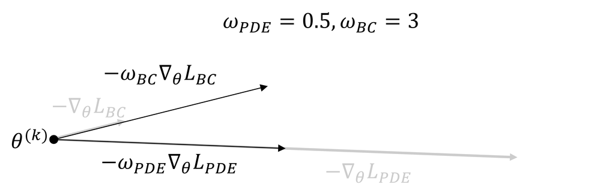

**Balanced at iteration $k$.** The unweighted gradients (grey) are badly mismatched. The weights $\omega_{\mathrm{PDE}} = 0.5$ and $\omega_{\mathrm{BC}} = 3$ shorten one and lengthen the other until the two scaled vectors (black) are comparable, and the step is a compromise between the two conditions.

## 6.1. A Well-Chosen Weight Recovers the Solution

With a large enough boundary weight,

$$ \mathcal{L}_{\mathrm{total}} = \mathcal{L}_{\mathrm{PDE}} + 10^{4}\,\mathcal{L}_{\mathrm{BC}} , $$

the two objectives are brought to a comparable footing. The value is of the order of the ratio of the two gradient norms over the course of training, which the adaptive run of Section 7 will measure.

```python
weight_bc = 1e4

net_fixed_good = new_pinn()
optimizer = torch.optim.Adam(net_fixed_good.parameters(), lr = lr)

for k in range(n_iter):
    optimizer.zero_grad()

    u = net_fixed_good(x_pde)
    u_x = derivative(u, x_pde)
    u_xx = derivative(u_x, x_pde)

    loss_pde = torch.mean((-u_xx - f_pde)**2)
    loss_bc = torch.mean(net_fixed_good(x_bc)**2)
    loss = loss_pde + weight_bc*loss_bc

    loss.backward()
    optimizer.step()

print('Fixed, weight_bc = 1e4 | PDE %.3e | BC %.3e' % (loss_pde.item(), loss_bc.item()))
```

```
Fixed, weight_bc = 1e4 | PDE 8.620e-03 | BC 8.283e-10
```

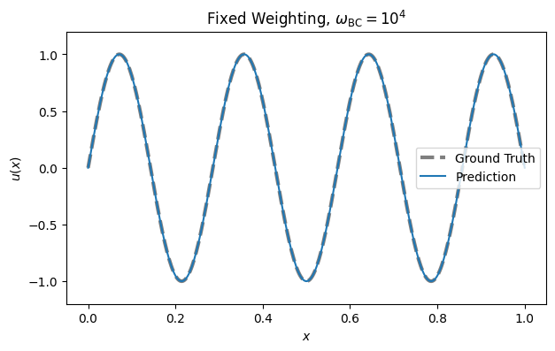

```python
with torch.no_grad():
    u_fixed_good = net_fixed_good(x_plot).cpu().numpy().ravel()

plt.figure(figsize = (7, 4))
plt.plot(x_np, u_true, 'k--', linewidth = 3, label = 'Ground Truth', alpha = 0.5)
plt.plot(x_np, u_fixed_good, linewidth = 1.5, label = 'Prediction')
plt.title(r'Fixed Weighting, $\omega_{\mathrm{BC}} = 10^4$')
plt.xlabel('$x$')
plt.ylabel('$u(x)$')
plt.ylim(-1.2, 1.2)
plt.legend()
plt.show()
```

## 6.2. A Badly Chosen Weight Converges to the Wrong Answer

The same strategy with a smaller boundary weight,

$$ \mathcal{L}_{\mathrm{total}} = \mathcal{L}_{\mathrm{PDE}} + 10^{2}\,\mathcal{L}_{\mathrm{BC}} , $$

is a hundred times stronger than the naive formulation and still two orders of magnitude short of the previous run.

```python
weight_bc = 1e2

net_fixed_bad = new_pinn()
optimizer = torch.optim.Adam(net_fixed_bad.parameters(), lr = lr)

for k in range(n_iter):
    optimizer.zero_grad()

    u = net_fixed_bad(x_pde)
    u_x = derivative(u, x_pde)
    u_xx = derivative(u_x, x_pde)

    loss_pde = torch.mean((-u_xx - f_pde)**2)
    loss_bc = torch.mean(net_fixed_bad(x_bc)**2)
    loss = loss_pde + weight_bc*loss_bc

    loss.backward()
    optimizer.step()

print('Fixed, weight_bc = 1e2 | PDE %.3e | BC %.3e' % (loss_pde.item(), loss_bc.item()))
```

```
Fixed, weight_bc = 1e2 | PDE 1.688e+04 | BC 2.026e-07
```

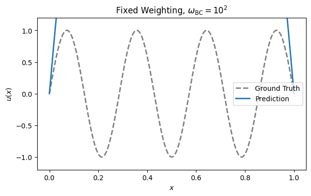

```python
with torch.no_grad():
    u_fixed_bad = net_fixed_bad(x_plot).cpu().numpy().ravel()

plt.figure(figsize = (7, 4))
plt.plot(x_np, u_true, 'k--', linewidth = 2, label = 'Ground Truth', alpha = 0.5)
plt.plot(x_np, u_fixed_bad, linewidth = 2, label = 'Prediction')
plt.title(r'Fixed Weighting, $\omega_{\mathrm{BC}} = 10^2$')
plt.xlabel('$x$')
plt.ylabel('$u(x)$')
plt.ylim(-1.2, 1.2)
plt.legend()
plt.show()
```

The boundary loss is small, so the two ends are pinned at zero. Everything between them is wrong: the prediction shoots off the plotting window within a few hundredths of either end, and the PDE residual is as large as in the naive run. A weight of $10^{2}$ was enough to enforce the boundary values, and not enough to keep the interior from the same large-amplitude function that the naive PINN found.

## 6.3. Two Limitations of a Fixed Weight

The two runs expose two separate difficulties, and it is worth keeping them apart, because they call for different remedies.

The first is that **the right value is not known in advance**. The weight $10^{4}$ was found by trying values, with the exact solution available to judge them, which is not a procedure available on a problem whose solution is unknown. A sweep over weights, with some independent check of the answer, can address this, at the cost of many training runs.

The second is that **even a right value does not stay right**. The relative scales of the two gradients change as the network moves through parameter space, so a pair of constants that balances them at one iteration over-corrects at another, and the competition reappears with the roles reversed. The two figures show the sequence. No sweep can address this, because the quantity being tuned is not a constant of the problem at all. The remedy has to read the gradients as they are, not as they were, which is **adaptive weighting**.

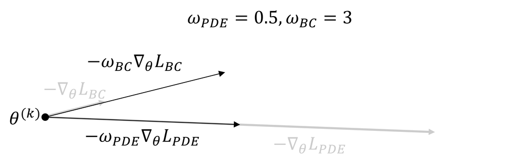

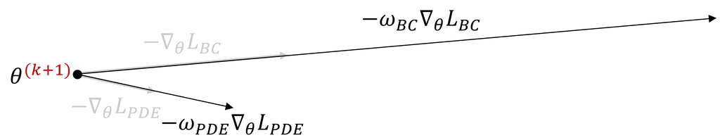

**The same weights at iteration $k+1$.** The network has moved, the unweighted gradients have changed, and the fixed weights now make the boundary term dominant. The imbalance is back, in the other direction. Nothing short of re-reading the gradients can keep the balance.

# 7. Adaptive Weighting

## 7.1. The Optimizer Sees Gradients, Not Losses

The optimizer receives only the combined scalar $\mathcal{L}_{\mathrm{total}}$. It does not know that the first term is a statement about the interior and the second a statement about the boundary, or that a function satisfying one and not the other is not a solution at all. It sees one number and descends. Whatever went wrong in Section 5.2 went wrong inside that one number.

The parameters are updated by gradient descent on the total loss, with learning rate $\eta$,

$$ \theta^{(k+1)} = \theta^{(k)} - \eta\,\nabla_\theta\mathcal{L}_{\mathrm{total}} . $$

Because the objective is a sum, so is its gradient,

$$ \nabla_\theta\mathcal{L}_{\mathrm{total}} = \nabla_\theta\mathcal{L}_{\mathrm{PDE}} + \nabla_\theta\mathcal{L}_{\mathrm{BC}} . $$

The step is the sum of two vectors in parameter space, one per condition, and the optimizer follows the sum. What decides the direction of the step is therefore the **gradient contribution** of each term, the length and direction of its vector, and not the scalar value of the loss. A small loss can have a long gradient, and a large loss can be nearly flat in $\theta$.

[figure not shown]

**Gradient descent.** Left: on a function of one variable, each step is taken against the slope. Right: on a surface, each step follows the negative gradient of the total loss. The optimizer never asks which term that gradient came from.

## 7.2. Gradient-Based Adaptive Weighting

Adaptive methods compute the coefficients from signals available during training and update them as training proceeds. The schemes differ in which signal they read.

| Method | Signal it reads | Core idea |
| --- | --- | --- |
| Gradient-based | gradient norms $\lVert\nabla_\theta\mathcal{L}_i\rVert$ | balance the contribution of each term to the update |
| Loss-based | loss values and their rate of decrease | upweight terms that are large or decaying slowly |
| Trainable weights | the objective itself | treat the weights as parameters and optimize them |
| NTK-based | the neural tangent kernel | upweight the terms the network learns most slowly |

This notebook uses the first, because the imbalance in question is an imbalance of parameter gradients, and the gradient-based rule acts on exactly that quantity.

$$ \begin{align*} \mathcal{L}_{\mathrm{total}} &= \omega_{\mathrm{PDE}}\mathcal{L}_{\mathrm{PDE}} + \omega_{\mathrm{BC}}\,\mathcal{L}_{\mathrm{BC}} \\\\ \nabla_\theta\mathcal{L}_{\mathrm{total}} &= \omega_{\mathrm{PDE}} \nabla_\theta\mathcal{L}_{\mathrm{PDE}} + \omega_{\mathrm{BC}}\nabla_\theta\mathcal{L}_{\mathrm{BC}} \end{align*} $$

For each loss term, measure the length of its gradient,

$$ g_i = \bigl\lVert \nabla_\theta\mathcal{L}_i \bigr\rVert_2 , $$

and their mean, and set each weight to the ratio of the two,

$$ \bar g = \frac{g_{\mathrm{PDE}} + g_{\mathrm{BC}}}{2} , \qquad \omega_i = \frac{\bar g}{g_i + \varepsilon} , $$

with a small $\varepsilon > 0$ against division by zero. The term with the longer gradient receives the smaller weight and the term with the shorter gradient the larger one, so that every scaled gradient $\omega_i g_i$ has length $\bar g$. The weights are recomputed at every iteration from the current gradients, and so they follow the network as it moves. Both limitations of Section 6.3 are addressed at once: no value has to be guessed, and the value is never stale.

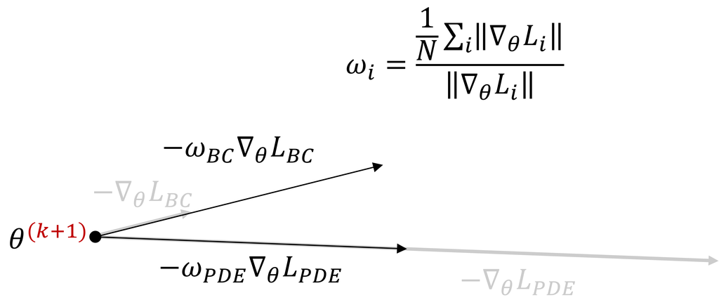

**Gradient-based rebalancing.** At iteration $k+1$ the weights are recomputed from the current gradient norms, $\omega_i = \bar g / g_i$, and the two scaled vectors are brought back to the same length. The balance of the previous figure is restored without any hand-tuned constant.

**Adaptive weighting**

`grad_norm` measures the length of the gradient of one loss term with respect to every parameter of the network, which is the quantity the rule of Section 7.2 reads. The weights are recomputed from the two lengths at every iteration and treated as plain numbers, so that they scale the losses without being differentiated themselves. Both losses and both weights are recorded throughout, so that the two conditions can be compared with the naive run of Section 5.2 and the weights with what was chosen by hand in Section 6.

```python
def grad_norm(loss, net):
    grads = torch.autograd.grad(loss, net.parameters(), retain_graph = True, allow_unused = True)
    total = 0.0
    for g in grads:
        if g is not None:                      # the output bias does not enter u_xx
            total = total + torch.sum(g**2)
    return torch.sqrt(total).item()

net_adapt = new_pinn()
optimizer = torch.optim.Adam(net_adapt.parameters(), lr = lr)

loss_pde_hist = np.zeros(n_iter)
loss_bc_hist = np.zeros(n_iter)
weight_pde_hist = np.zeros(n_iter)
weight_bc_hist = np.zeros(n_iter)

for k in range(n_iter):
    optimizer.zero_grad()

    u = net_adapt(x_pde)
    u_x = derivative(u, x_pde)
    u_xx = derivative(u_x, x_pde)

    loss_pde = torch.mean((-u_xx - f_pde)**2)
    loss_bc = torch.mean(net_adapt(x_bc)**2)

    g_pde = grad_norm(loss_pde, net_adapt)
    g_bc = grad_norm(loss_bc, net_adapt)
    g_mean = (g_pde + g_bc)/2
    weight_pde = g_mean/(g_pde + 1e-12)
    weight_bc = g_mean/(g_bc + 1e-12)

    loss = weight_pde*loss_pde + weight_bc*loss_bc

    loss.backward()
    optimizer.step()

    loss_pde_hist[k] = loss_pde.item()
    loss_bc_hist[k] = loss_bc.item()
    weight_pde_hist[k] = weight_pde
    weight_bc_hist[k] = weight_bc

print('Adaptive | PDE %.3e | BC %.3e' % (loss_pde.item(), loss_bc.item()))
print('Final weights | PDE %.3e | BC %.3e' % (weight_pde, weight_bc))
```

```
Adaptive | PDE 1.649e-02 | BC 3.397e-14
Final weights | PDE 5.000e-01 | BC 7.992e+04
```

[figure not shown]

```python
with torch.no_grad():
    u_adapt = net_adapt(x_plot).cpu().numpy().ravel()

plt.figure(figsize = (7, 10))

plt.subplot(3, 1, 1)
plt.plot(x_np, u_true, 'k--', linewidth = 3, label = 'Ground Truth', alpha = 0.5)
plt.plot(x_np, u_adapt, linewidth = 1.5, label = 'Prediction')
plt.title('Adaptive Weighting')
plt.xlabel('$x$')
plt.ylabel('$u(x)$')
plt.ylim(-1.2, 1.2)
plt.legend()

plt.subplot(3, 1, 2)
plt.semilogy(iteration, loss_pde_hist, label = r'$\mathcal{L}_{\mathrm{PDE}}$')
plt.semilogy(iteration, loss_bc_hist, label = r'$\mathcal{L}_{\mathrm{BC}}$')
plt.xlabel('Iteration')
plt.ylabel('Loss')
plt.legend()

plt.subplot(3, 1, 3)
plt.semilogy(iteration, weight_pde_hist, label = r'$\omega_{\mathrm{PDE}}$')
plt.semilogy(iteration, weight_bc_hist, label = r'$\omega_{\mathrm{BC}}$')
plt.xlabel('Iteration')
plt.ylabel('Weight')
plt.legend()

plt.tight_layout()
plt.show()
```

This panel is the retrospective verdict on Section 6. The fixed weight $10^{4}$ sits at the lower edge of the band the rule chose, which is why it worked; the fixed weight $10^{2}$ is a hundred times below it, which is why it did not. And the band is two decades wide and never settles, which is the second limitation of Section 6.3 made visible: the right weight is not a number but a moving target, and a constant can only ever be right on average.

## 7.3. Moving-Average Adaptive Weighting

The rule of Section 7.2 trusts a single measurement. The gradient norms are read at one iteration and the weights are set from them, and the bottom panel of that figure shows the consequence: $\omega_{\mathrm{BC}}$ jumps by a factor of ten or a hundred from one iteration to the next, because the boundary gradient itself does. Each of those jumps is passed straight into the update. The remedy is the one used wherever a noisy measurement drives a control: do not replace the weight by the new measurement, move it part of the way there,

$$ \hat\omega_i^{(k)} = \frac{\bar g^{(k)}}{g_i^{(k)} + \varepsilon}, \qquad \omega_i^{(k)} = (1 - \alpha)\,\omega_i^{(k-1)} + \alpha\,\hat\omega_i^{(k)} , $$

with $0 < \alpha \le 1$. This is an exponential moving average of the instantaneous weights. At $\alpha = 1$ it is Section 7.2; at small $\alpha$ the weight remembers roughly the last $1/\alpha$ measurements and a single spike moves it by a fraction $\alpha$ of the spike. This run uses $\alpha = 0.01$, a memory of about a hundred iterations, and starts both weights at $1$, so that the first hundred iterations are a ramp from the naive objective to the balanced one.

**Moving-average adaptive weighting**

The code is that of Section 7.2 with two lines changed, the ones that update the weights, and the two weights initialized before the loop. The instantaneous weight $\hat\omega_{\mathrm{BC}}$ is recorded alongside the averaged one so that the two can be drawn together.

```python
alpha_ma = 0.01

net_ma = new_pinn()
optimizer = torch.optim.Adam(net_ma.parameters(), lr = lr)

weight_pde, weight_bc = 1.0, 1.0

loss_pde_hist = np.zeros(n_iter)
loss_bc_hist = np.zeros(n_iter)
weight_bc_raw = np.zeros(n_iter)
weight_bc_hist = np.zeros(n_iter)

for k in range(n_iter):
    optimizer.zero_grad()

    u = net_ma(x_pde)
    u_x = derivative(u, x_pde)
    u_xx = derivative(u_x, x_pde)

    loss_pde = torch.mean((-u_xx - f_pde)**2)
    loss_bc = torch.mean(net_ma(x_bc)**2)

    g_pde = grad_norm(loss_pde, net_ma)
    g_bc = grad_norm(loss_bc, net_ma)
    g_mean = (g_pde + g_bc)/2
    weight_pde_new = g_mean/(g_pde + 1e-12)
    weight_bc_new = g_mean/(g_bc + 1e-12)

    weight_pde = (1 - alpha_ma)*weight_pde + alpha_ma*weight_pde_new
    weight_bc = (1 - alpha_ma)*weight_bc + alpha_ma*weight_bc_new

    loss = weight_pde*loss_pde + weight_bc*loss_bc

    loss.backward()
    optimizer.step()

    loss_pde_hist[k] = loss_pde.item()
    loss_bc_hist[k] = loss_bc.item()
    weight_bc_raw[k] = weight_bc_new
    weight_bc_hist[k] = weight_bc

print('Moving average | PDE %.3e | BC %.3e' % (loss_pde.item(), loss_bc.item()))
print('Final weights | PDE %.3e | BC %.3e' % (weight_pde, weight_bc))
```

```
Moving average | PDE 1.056e-01 | BC 7.544e-10
Final weights | PDE 5.000e-01 | BC 1.187e+04
```

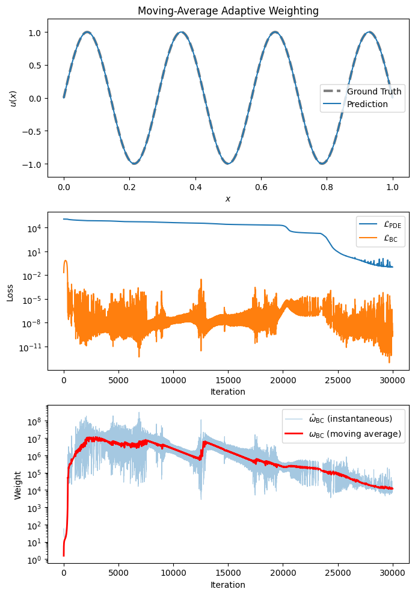

```python
with torch.no_grad():
    u_ma = net_ma(x_plot).cpu().numpy().ravel()

plt.figure(figsize = (7, 10))

plt.subplot(3, 1, 1)
plt.plot(x_np, u_true, 'k--', linewidth = 3, label = 'Ground Truth', alpha = 0.5)
plt.plot(x_np, u_ma, linewidth = 1.5, label = 'Prediction')
plt.title('Moving-Average Adaptive Weighting')
plt.xlabel('$x$')
plt.ylabel('$u(x)$')
plt.ylim(-1.2, 1.2)
plt.legend()

plt.subplot(3, 1, 2)
plt.semilogy(iteration, loss_pde_hist, label = r'$\mathcal{L}_{\mathrm{PDE}}$')
plt.semilogy(iteration, loss_bc_hist, label = r'$\mathcal{L}_{\mathrm{BC}}$')
plt.xlabel('Iteration')
plt.ylabel('Loss')
plt.legend()

plt.subplot(3, 1, 3)
plt.semilogy(iteration, weight_bc_raw, linewidth = 0.8, alpha = 0.4, label = r'$\hat\omega_{\mathrm{BC}}$ (instantaneous)')
plt.semilogy(iteration, weight_bc_hist, 'r', linewidth = 2, label = r'$\omega_{\mathrm{BC}}$ (moving average)')
plt.xlabel('Iteration')
plt.ylabel('Weight')
plt.legend()

plt.tight_layout()
plt.show()
```

## 7.4. What Adaptive Weighting Does Not Do

Adaptive weighting rebalances the competition without ending it. Every condition is still a penalty, satisfied only approximately, and the boundary values of the adaptive run are small, not zero. The moving average of Section 7.3 tames the swings of the measured weights but does not change this: a smoothed penalty is still a penalty. The method removes the need to guess a constant. It does not remove the boundary term from the objective, and for a condition that can be written in closed form there is a more direct option.

# 8. Hard Constraint by a Masking Function

## 8.1. Building the Boundary Condition into the Output

A hard constraint attacks the competition from the other side. Instead of adjusting how strongly a condition is penalized, the output of the network is built so that the condition holds for every value of $\theta$, and the corresponding loss term disappears, together with its weight. For the homogeneous Dirichlet condition of this problem, write

$$ u_\theta^{\mathrm{hard}}(x) = 4x(1-x)\,N_\theta(x) , $$

where $N_\theta$ is the network. This is the masking-function construction of **Embedding Physical Knowledge into Neural Networks**, applied to the boundary condition of a PINN. The multiplier vanishes at both ends, so

$$ u_\theta^{\mathrm{hard}}(0) = u_\theta^{\mathrm{hard}}(1) = 0 $$

identically, whatever the network returns there. The boundary condition is removed from the gradient competition altogether, no weight has to be chosen for it, and training minimizes the PDE residual alone. The price is a change of hypothesis space: the network now represents $u / 4x(1-x)$ rather than $u$, and the multiplier has to be designed so that it enforces the condition without making the interior harder to represent. When the condition has a simple closed form, as here, the construction is almost always preferable to a penalty, for the same reason that eliminating a variable is preferable to constraining it.

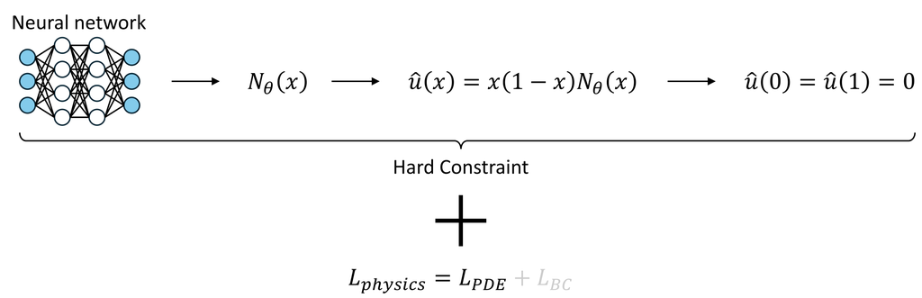

**Hard constraint.** The network output $N_\theta(x)$ is multiplied by a function that vanishes at both ends, so $\hat u(0) = \hat u(1) = 0$ holds by construction and the boundary term drops out of the loss. The factor $4$ used in the code only rescales the network output and changes nothing about the constraint.

**Hard-constrained PINN**

The same network, points, optimizer and starting weights as every run before; only the definition of $u$ and the loss change, and the loss is now the PDE term alone. The boundary loss is evaluated once at the end, to confirm that it is zero.

```python
net_hard = new_pinn()
optimizer = torch.optim.Adam(net_hard.parameters(), lr = lr)

for k in range(n_iter):
    optimizer.zero_grad()

    u = 4*x_pde*(1 - x_pde)*net_hard(x_pde)       # zero at both ends, whatever the network says
    u_x = derivative(u, x_pde)
    u_xx = derivative(u_x, x_pde)

    loss_pde = torch.mean((-u_xx - f_pde)**2)     # no BC term

    loss_pde.backward()
    optimizer.step()

with torch.no_grad():
    u_hard = (4*x_plot*(1 - x_plot)*net_hard(x_plot)).cpu().numpy().ravel()
    loss_bc = torch.mean((4*x_bc*(1 - x_bc)*net_hard(x_bc))**2)

print('Hard constraint | PDE %.3e | BC %.3e' % (loss_pde.item(), loss_bc.item()))
```

```
Hard constraint | PDE 5.056e-03 | BC 0.000e+00
```

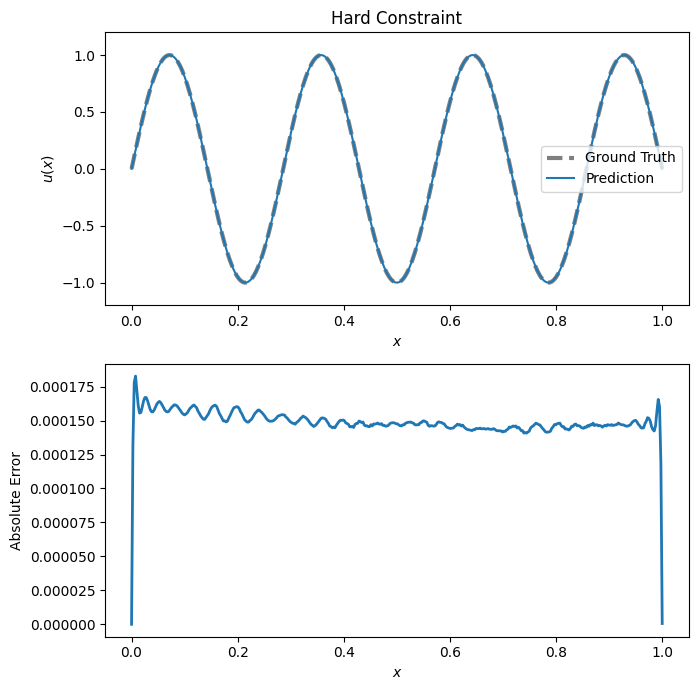

```python
error = np.abs(u_hard - u_true)

plt.figure(figsize = (7, 7))

plt.subplot(2, 1, 1)
plt.plot(x_np, u_true, 'k--', linewidth = 3, label = 'Ground Truth', alpha = 0.5)
plt.plot(x_np, u_hard, linewidth = 1.5, label = 'Prediction')
plt.title('Hard Constraint')
plt.xlabel('$x$')
plt.ylabel('$u(x)$')
plt.ylim(-1.2, 1.2)
plt.legend()

plt.subplot(2, 1, 2)
plt.plot(x_np, error, linewidth = 2)
plt.xlabel('$x$')
plt.ylabel('Absolute Error')

plt.tight_layout()
plt.show()
```

The hard-constrained model is the most accurate of the four. The PDE residual is the smallest in the notebook, and the boundary loss is exactly zero, not because it was minimized but because it was never possible for it to be anything else. The error panel shows the signature of the construction: the error is small and smooth across the interior and drops to exactly zero at $x = 0$ and $x = 1$, where the multiplier vanishes. There was no boundary term to weight and nothing to trade the interior against, so every gradient step went into the equation.

## 8.2. Where the Argument Ends

The five steps close on a hierarchy that is worth stating plainly. Impose exactly what can be imposed exactly, as the hard constraint does for the boundary condition. Penalize the rest, because a penalty can be written for a requirement that admits no parameterization, an inequality, an integral conservation law, a condition on an unknown interface. And weight the penalties by what their gradients say, not by what their loss values say, letting the gradients choose the weight when the right value is unknown or changes during training. A naive sum is the special case in which none of this has been thought about, and Section 5.2 is what it costs.

# Summary

**Key takeaways**

**Looking ahead.** Weighting and masking deal with conditions that compete for the parameters. The remaining limitations of a PINN are of a different kind: the collocation points can miss the part of the domain that matters, the solution can have a shape that a smooth network does not easily represent, and a transient problem can be trained without regard to the direction of time. **PINN: Limitations and Overcoming Strategies** takes these up.